# BHRe episodes — descriptive analysis

Episodes and cases by year, region, facility type, mechanism and microorganism

09 July 2026

# 1 What this report covers

Each **episode** is one row (`ehesp_id`); the episode **date** is `first_positive_sample_date`. **Cases** are the number of patients in an episode (`n_total_if_secondary_cases`, treated as 1 when not recorded — i.e. the index case). We describe episodes and cases by **year, region, facility type**, their combinations, and **over time**, first for all resistance mechanisms together and then broken down by **mechanism** (from mechanism slots 1 and 2) and by **microorganism** (all species slots). Finally we map both onto France.

> When we break down **by mechanism** or **by microorganism**, an episode that carries two mechanisms (or two species) is counted under each. Group totals can therefore add up to more than the overall total — this is expected.

# 2 Load and link

```r
bhre = readRDS(here("Datasets" , "Sante Publique","Cleaned", "bhre_hosp_clean.RDS"))
```

# 3 Build the analysis variables

```r
# ---- reference maps ----
species_map <- c(
  CITFRE="Citrobacter freundii", CITKOS="Citrobacter koseri", CITSPP="Citrobacter spp.",
  ENCFAC="Enterococcus faecium", ENTAER="Enterobacter aerogenes", ENTCLO="Enterobacter cloacae",
  ENTSPP="Enterobacter spp.", ESCCOL="Escherichia coli", ESCSPP="Escherichia spp.",
  ETBAUT="Enterobacterales (other)", ETBNON="Enterobacterales (unspecified)",
  KLEOXY="Klebsiella oxytoca", KLEPNE="Klebsiella pneumoniae", KLESPP="Klebsiella spp.",
  MOGMOR="Morganella morganii", PROSPP="Proteus spp.", PRTMIR="Proteus mirabilis",
  RAOSPP="Raoultella spp.", SALSPP="Salmonella spp.", SERMAR="Serratia marcescens")

oxa48_like <- c("OXA-48","OXA-48-LIKE","OXA-181","OXA-204","OXA-244","OXA-162","OXA-232")
mech_family_one <- function(x) {
  x <- toupper(trimws(x)); if (is.na(x) || x == "") return(NA_character_)
  if (x %in% oxa48_like || str_starts(x, "OXA-48")) return("OXA-48 group")
  if (str_starts(x, "KPC")) return("KPC");  if (str_starts(x, "NDM")) return("NDM")
  if (str_starts(x, "VIM")) return("VIM");  if (str_starts(x, "IMP")) return("IMP")
  if (str_starts(x, "IMI")) return("IMI")
  if (str_starts(x, "VAN") || str_detect(x, "GLYCOPEPTIDE")) return("Glycopeptide (GRE)")
  if (str_starts(x, "MCR")) return("mcr (colistin)")
  "Unspecified / other"
}

# ---- one row per episode with core dimensions ----
epi <- bhre %>%
  mutate(
    date        = as.Date(first_positive_sample_date),
    year        = year(date),
    month       = floor_date(date, "month"),
    cases       = pmax(coalesce(as.integer(n_total_if_secondary_cases), 1L), 1L),
    region      = str_squish(region),
    facility_type = .data[[params$facility_type_col]]
  ) %>%
  filter(!is.na(date))
```

Overall totals

| measure | value |
| --- | --- |
| Episodes (rows) | 17990 |
| Cases (patients) | 28075 |
| Facilities | 0 |
| Date range | 1980-06-06 to 2025-12-31 |

# 4 Episodes and cases by year of first specimen collection date

```r
by_year <- epi %>% group_by(year) %>%
  summarise(episodes = n(), cases = sum(cases), .groups = "drop")
kable(by_year, caption = "Episodes and cases by year")
```

Episodes and cases by year

| year | episodes | cases |
| --- | --- | --- |
| 1980 | 1 | 1 |
| 2013 | 1 | 10 |
| 2016 | 5 | 8 |
| 2017 | 678 | 856 |
| 2018 | 2123 | 2963 |
| 2019 | 2528 | 3258 |
| 2020 | 1430 | 2079 |
| 2021 | 1592 | 2505 |
| 2022 | 2450 | 4293 |
| 2023 | 2688 | 4191 |
| 2024 | 2437 | 4161 |
| 2025 | 2057 | 3750 |

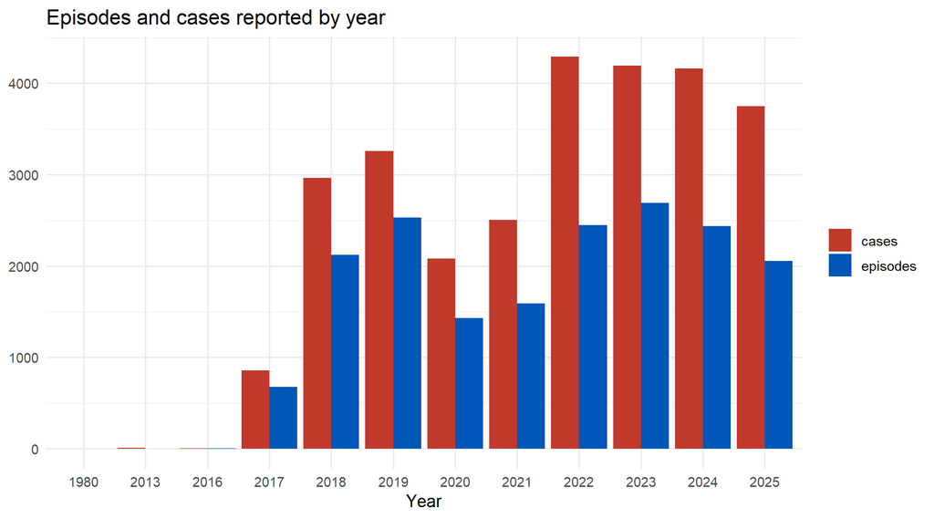

```r
by_year %>% pivot_longer(c(episodes, cases)) %>%
  ggplot(aes(factor(year), value, fill = name)) +
  geom_col(position = "dodge") +
  labs(x = "Year", y = NULL, fill = NULL, title = "Episodes and cases reported by year") +
  scale_fill_manual(values = c(episodes = "#0057B8", cases = "#C1392B"))
```

For future analyses, we will limit the analyses to cases beginning in 2017.

# 5 Episodes and cases by region

```r
library(tidyverse)
epi = filter(epi, year(first_positive_sample_date) >2016)

by_region <- epi %>% filter(!is.na(region)) %>% group_by(region) %>%
  summarise(episodes = n(), cases = sum(cases), .groups = "drop") %>%
  arrange(desc(episodes))
kable(by_region, caption = "Episodes and cases by region")
```

Episodes and cases by region

| region | episodes | cases |
| --- | --- | --- |
| Île-de-France | 5634 | 7157 |
| Hauts-de-France | 2297 | 3926 |
| Auvergne-Rhône-Alpes | 1907 | 3303 |
| Occitanie | 1547 | 2134 |
| Provence-Alpes-Côte d’Azur | 1272 | 2074 |
| Grand-Est | 1149 | 2407 |
| Nouvelle-Aquitaine | 633 | 1188 |
| Normandie | 556 | 702 |
| Pays de la Loire | 553 | 1033 |
| Centre-Val de Loire | 359 | 485 |
| Bourgogne-Franche-Comté | 322 | 468 |
| Bretagne | 314 | 602 |

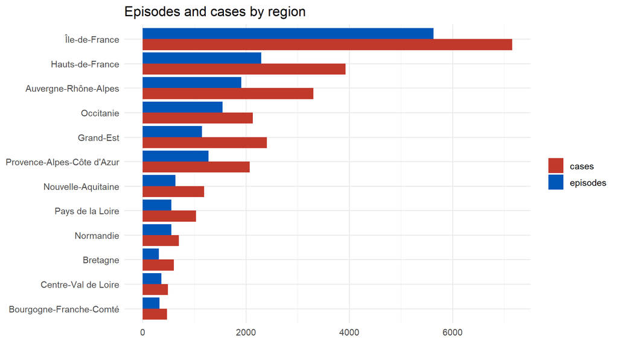

```r
by_region %>% pivot_longer(c(episodes, cases)) %>%
  ggplot(aes(fct_reorder(region, value), value, fill = name)) +
  geom_col(position = "dodge") + coord_flip() +
  labs(x = NULL, y = NULL, fill = NULL, title = "Episodes and cases by region") +
  scale_fill_manual(values = c(episodes = "#0057B8", cases = "#C1392B"))
```

# 6 Episodes and cases by facility type

```r
#Looking at how many episodes matched a facility in our network data
library(janitor)
fac_epi = tabyl(epi$facility_type)

kable(fac_epi, caption = "Breakdown of all facility types with episodes, including NAs")
```

Breakdown of all facility types with episodes, including NAs

| epi$facility_type | n | percent | valid_percent |
| --- | --- | --- | --- |
| Cancer centre (CLCC) | 488 | 0.0271367 | 0.0294971 |
| General public hospital (CH) | 6638 | 0.3691264 | 0.4012331 |
| Non-profit facility (PSPH/EBNL) | 1473 | 0.0819107 | 0.0890353 |
| Private | 1765 | 0.0981483 | 0.1066852 |
| Regional/University hospital (CHR/U) | 6180 | 0.3436579 | 0.3735493 |
| NA | 1439 | 0.0800200 | NA |

```r
by_fac <- epi %>% filter(!is.na(facility_type)) %>% group_by(facility_type) %>%
  summarise(episodes = n(), cases = sum(cases), .groups = "drop") %>%
  arrange(desc(episodes))
kable(by_fac, caption = "Episodes and cases by facility type, 2017-2025", subtitle = "NAs removed")
```

Episodes and cases by facility type, 2017-2025

| facility_type | episodes | cases |
| --- | --- | --- |
| General public hospital (CH) | 6638 | 11417 |
| Regional/University hospital (CHR/U) | 6180 | 8874 |
| Private | 1765 | 2317 |
| Non-profit facility (PSPH/EBNL) | 1473 | 2219 |
| Cancer centre (CLCC) | 488 | 653 |

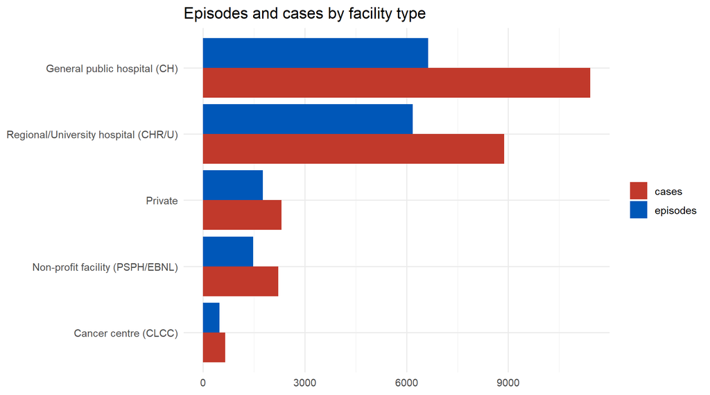

```r
by_fac %>% pivot_longer(c(episodes, cases)) %>%
  ggplot(aes(fct_reorder(facility_type, value), value, fill = name)) +
  geom_col(position = "dodge") + coord_flip() +
  labs(x = NULL, y = NULL, fill = NULL, title = "Episodes and cases by facility type") +
  scale_fill_manual(values = c(episodes = "#0057B8", cases = "#C1392B"))
```

```r
#Episodes by year and facility type
```

# 7 Combinations

## 7.1 Year × facility type

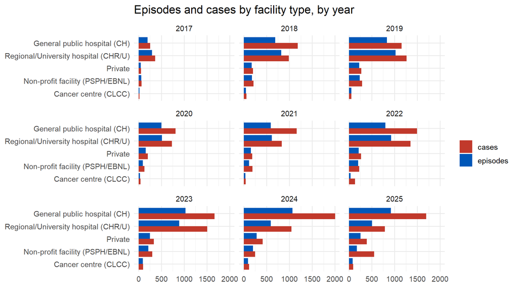

```r
by_fac_year <- epi %>% filter(!is.na(facility_type)) %>%
  group_by(year, facility_type) %>%
  summarise(episodes = n(), cases = sum(cases), .groups = "drop")

by_fac_year %>% pivot_longer(c(episodes, cases)) %>%
  ggplot(aes(fct_reorder(facility_type, value), value, fill = name)) +
  geom_col(position = "dodge") + coord_flip() +
  facet_wrap(~ year) +
  labs(x = NULL, y = NULL, fill = NULL,
       title = "Episodes and cases by facility type, by year") +
  scale_fill_manual(values = c(episodes = "#0057B8", cases = "#C1392B"))
```

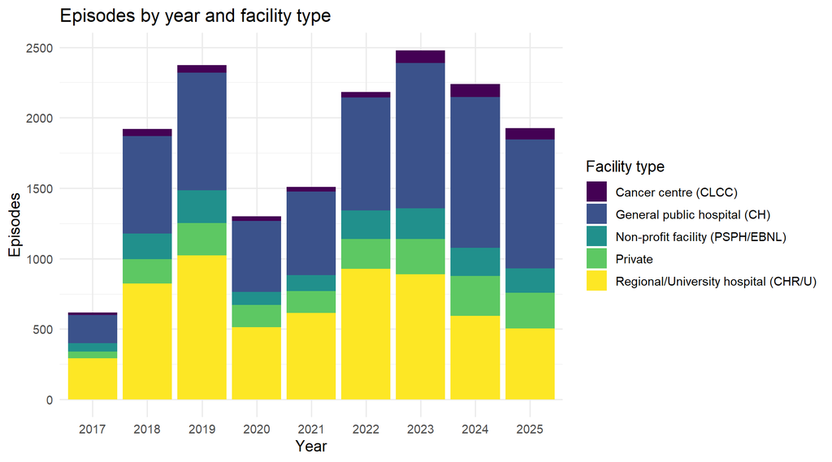

```r
# Episodes by year and facility type
epi %>% filter(!is.na(facility_type)) %>%
  count(year, facility_type, name = "episodes") %>%
  ggplot(aes(factor(year), episodes, fill = facility_type)) +
  geom_col() +
  labs(x = "Year", y = "Episodes", fill = "Facility type",
       title = "Episodes by year and facility type") + pal_fill()
```

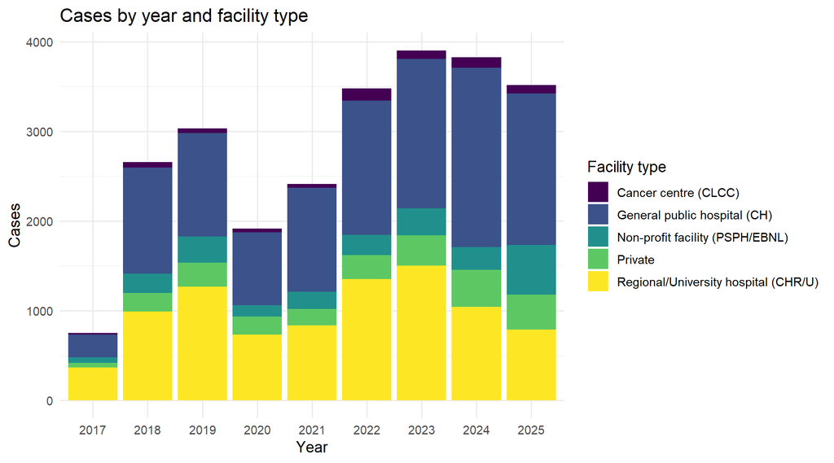

```r
# Cases by year and facility type
epi %>% filter(!is.na(facility_type)) %>%
  group_by(year, facility_type) %>%
  summarise(cases = sum(cases), .groups = "drop") %>%
  ggplot(aes(factor(year), cases, fill = facility_type)) +
  geom_col() +
  labs(x = "Year", y = "Cases", fill = "Facility type",
       title = "Cases by year and facility type") + pal_fill()
```

## 7.2 Region × facility type (episodes)

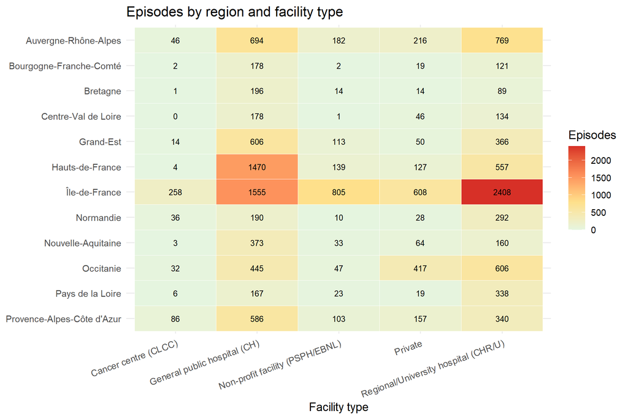

```r
epi %>% filter(!is.na(region), !is.na(facility_type)) %>%
  count(region, facility_type, name = "episodes") %>%
  tidyr::complete(region, facility_type, fill = list(episodes = 0)) %>%
  ggplot(aes(facility_type, fct_rev(region), fill = episodes)) +
  geom_tile(color = "white") +
  geom_text(aes(label = episodes), size = 3) +
  scale_fill_gradientn(colours = c("#E5F5E0", "#FEE08B", "#FC8D59", "#D73027")) +
  labs(x = "Facility type", y = NULL, fill = "Episodes",
       title = "Episodes by region and facility type") +
  theme(axis.text.x = element_text(angle = 20, hjust = 1))
```

# 8 Trends over time

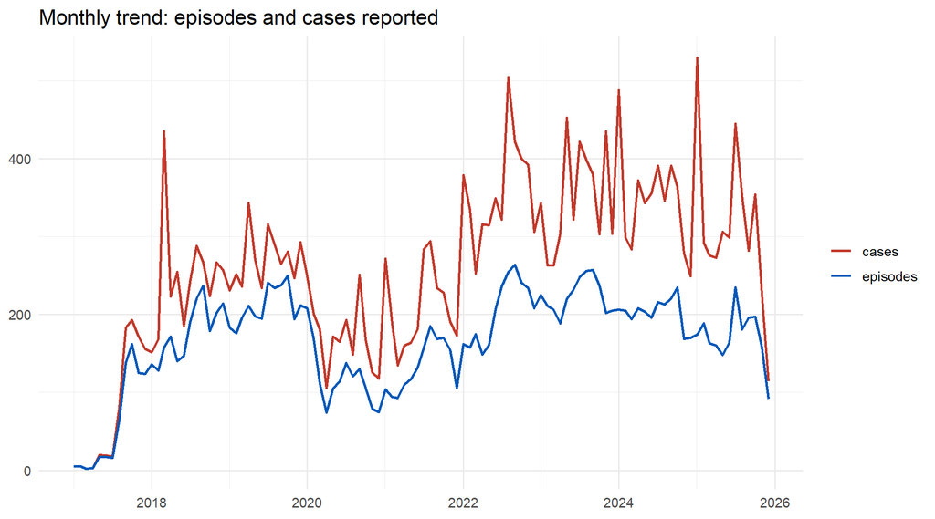

```r
by_month <- epi %>% group_by(month) %>%
  summarise(episodes = n(), cases = sum(cases), .groups = "drop")

by_month %>% pivot_longer(c(episodes, cases)) %>%
  ggplot(aes(month, value, color = name)) +
  geom_line(linewidth = 0.8) +
  scale_color_manual(values = c(episodes = "#0057B8", cases = "#C1392B")) +
  labs(x = NULL, y = NULL, color = NULL,
       title = "Monthly trend: episodes and cases reported")
```

# 9 By resistance mechanism

Mechanisms are read from slots 1 and 2 (`resistance_mechanism_1_1/1_2/2_1/2_2`) and grouped into families.

```r
mech_cols <- c("resistance_mechanism_1_1","resistance_mechanism_1_2",
               "resistance_mechanism_2_1","resistance_mechanism_2_2")
epi_mech <- epi %>%
  select(ehesp_id, year, month, region, facility_type, cases, all_of(mech_cols)) %>%
  pivot_longer(all_of(mech_cols), values_to = "mech") %>%
  filter(!is.na(mech), mech != "") %>%
  mutate(mech_family = map_chr(mech, mech_family_one)) %>%
  filter(!is.na(mech_family)) %>%
  distinct(ehesp_id, mech_family, .keep_all = TRUE)   # one episode-per-family row
```

## 9.1 Episodes and cases by mechanism family

```r
by_mech <- epi_mech %>% group_by(mech_family) %>%
  summarise(episodes = n_distinct(ehesp_id), cases = sum(cases), .groups = "drop") %>%
  arrange(desc(episodes))
kable(by_mech, caption = "Episodes and cases by mechanism family (episodes may appear in >1)")
```

Episodes and cases by mechanism family (episodes may appear in >1)

| mech_family | episodes | cases |
| --- | --- | --- |
| OXA-48 group | 10425 | 15521 |
| NDM | 4691 | 7136 |
| Glycopeptide (GRE) | 2033 | 4407 |
| VIM | 821 | 1319 |
| KPC | 558 | 690 |
| Unspecified / other | 489 | 607 |
| IMI | 55 | 59 |
| IMP | 22 | 23 |
| mcr (colistin) | 5 | 5 |

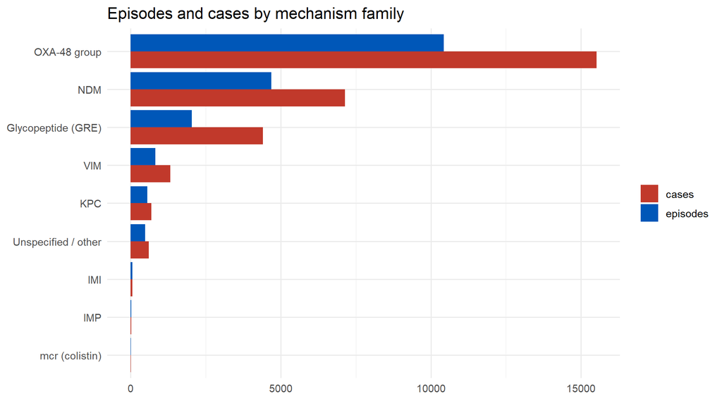

```r
by_mech %>% pivot_longer(c(episodes, cases)) %>%
  ggplot(aes(fct_reorder(mech_family, value), value, fill = name)) +
  geom_col(position = "dodge") + coord_flip() +
  labs(x = NULL, y = NULL, fill = NULL, title = "Episodes and cases by mechanism family") +
  scale_fill_manual(values = c(episodes = "#0057B8", cases = "#C1392B"))
```

# 10 Episode Duration (First to Last Case Date)

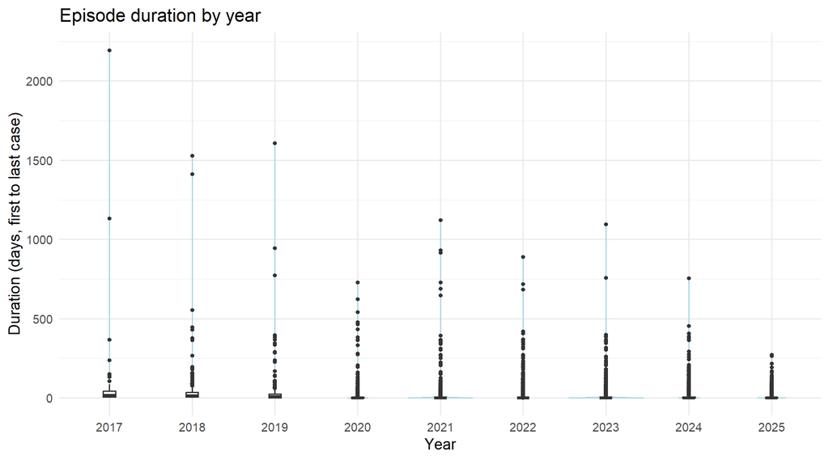

```r
# duration, dropping the negatives/NAs once
epi_dur <- epi %>%
  mutate(duration_days = as.numeric(as.Date(last_case_date) - date)) %>%
  filter(!is.na(duration_days), duration_days >= 0)


ggplot(epi_dur, aes(factor(year), duration_days)) +
  geom_violin(fill = "#0057B8", alpha = 0.4, color = "lightblue") +
  geom_boxplot(width = 0.15, outlier.size = 1) +
  labs(x = "Year", y = "Duration (days, first to last case)",
       title = "Episode duration by year")
```

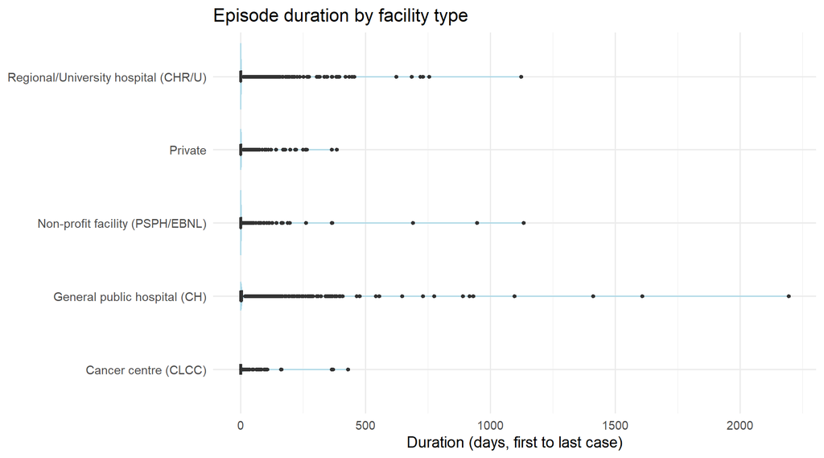

```r
ggplot(filter(epi_dur, !is.na(facility_type)),
       aes(fct_reorder(facility_type, duration_days, median), duration_days)) +
  geom_violin(fill = "#C1392B", alpha = 0.4, color = "lightblue") +
  geom_boxplot(width = 0.15, outlier.size = 1) +
  coord_flip() +
  labs(x = NULL, y = "Duration (days, first to last case)",
       title = "Episode duration by facility type")
```

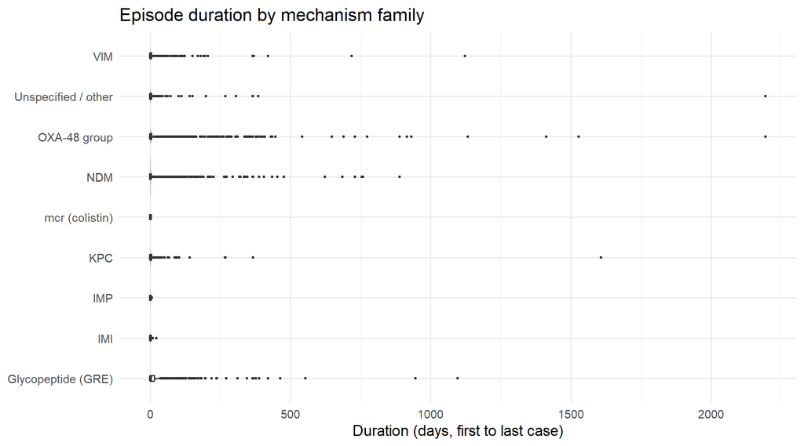

```r
# per-episode duration
epi_dur <- epi %>%
  mutate(duration_days = as.numeric(as.Date(last_case_date) - date)) %>%
  filter(!is.na(duration_days), duration_days >= 0)

# attach duration to the episode-mechanism long table
mech_dur <- epi_mech %>%
  inner_join(select(epi_dur, ehesp_id, duration_days), by = "ehesp_id")

ggplot(mech_dur, aes(fct_reorder(mech_family, duration_days, median), duration_days)) +
  geom_violin(fill = "#9B1D8A", alpha = 0.4, color = NA) +
  geom_boxplot(width = 0.15, outlier.size = 0.6) +
  coord_flip() +
  labs(x = NULL, y = "Duration (days, first to last case)",
       title = "Episode duration by mechanism family")
```

## 10.1 Mechanism families over time

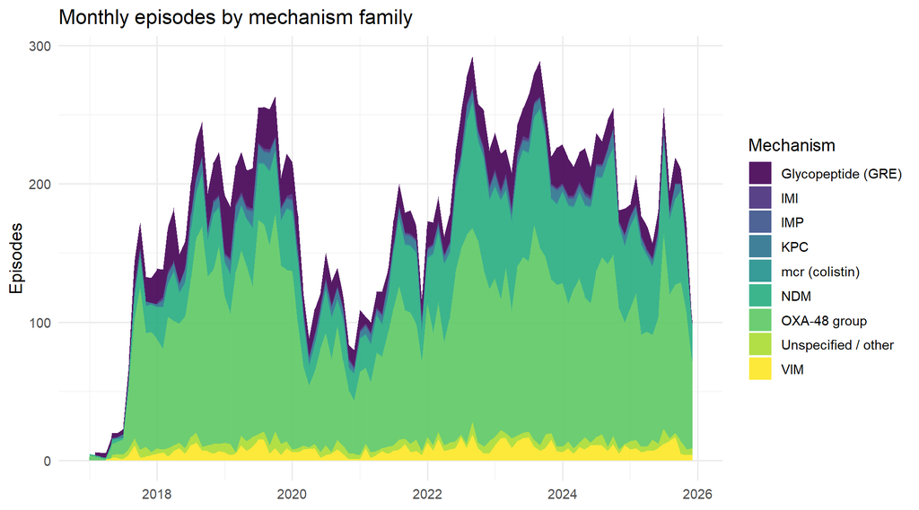

```r
epi_mech %>% count(month, mech_family, name = "episodes") %>%
  ggplot(aes(month, episodes, fill = mech_family)) +
  geom_area(alpha = 0.9) +
  labs(x = NULL, y = "Episodes", fill = "Mechanism",
       title = "Monthly episodes by mechanism family") + pal_fill()
```

## 10.2 Mechanism family by region

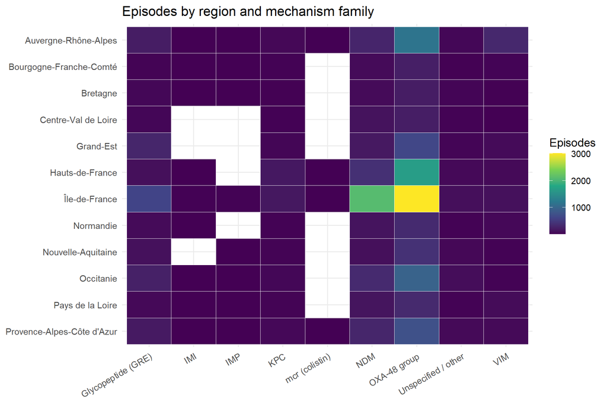

```r
epi_mech %>% filter(!is.na(region)) %>% count(region, mech_family, name = "episodes") %>%
  ggplot(aes(mech_family, fct_rev(region), fill = episodes)) +
  geom_tile(color = "white") + scale_fill_viridis_c() +
  labs(x = NULL, y = NULL, fill = "Episodes",
       title = "Episodes by region and mechanism family") +
  theme(axis.text.x = element_text(angle = 30, hjust = 1))
```

# 11 By microorganism (species)

```r
micro_cols <- c("microorganism_1","microorganism_2","microorganism_3")
epi_sp <- epi %>%
  select(ehesp_id, year, month, region, facility_type, cases, all_of(micro_cols)) %>%
  pivot_longer(all_of(micro_cols), values_to = "code") %>%
  filter(!is.na(code), code != "") %>%
  mutate(species = recode(str_sub(code, 1, 6), !!!species_map,
                          .default = str_sub(code, 1, 6))) %>%
  distinct(ehesp_id, species, .keep_all = TRUE)
```

## 11.1 Episodes and cases by species

```r
by_sp <- epi_sp %>% group_by(species) %>%
  summarise(episodes = n_distinct(ehesp_id), cases = sum(cases), .groups = "drop") %>%
  arrange(desc(episodes))
kable(by_sp, caption = "Episodes and cases by microorganism (episodes may appear in >1)")
```

Episodes and cases by microorganism (episodes may appear in >1)

| species | episodes | cases |
| --- | --- | --- |
| Escherichia coli | 6138 | 8287 |
| Klebsiella pneumoniae | 5102 | 7593 |
| Citrobacter freundii | 2468 | 4365 |
| Enterobacter cloacae | 2324 | 3941 |
| Enterococcus faecium | 2114 | 4493 |
| Klebsiella oxytoca | 583 | 1061 |
| Citrobacter spp. | 252 | 561 |
| Citrobacter koseri | 171 | 240 |
| Enterobacter aerogenes | 159 | 197 |
| Enterobacterales (unspecified) | 158 | 189 |
| Enterobacter spp. | 155 | 300 |
| Serratia marcescens | 117 | 137 |
| Klebsiella spp. | 113 | 247 |
| Enterobacterales (other) | 109 | 148 |
| Morganella morganii | 72 | 101 |
| Proteus mirabilis | 48 | 58 |
| Raoultella spp. | 37 | 55 |
| Escherichia spp. | 19 | 19 |
| Proteus spp. | 19 | 20 |
| Salmonella spp. | 5 | 6 |
| PRTSPP | 3 | 3 |
| PANTSP | 2 | 2 |
| SALTYP | 2 | 2 |

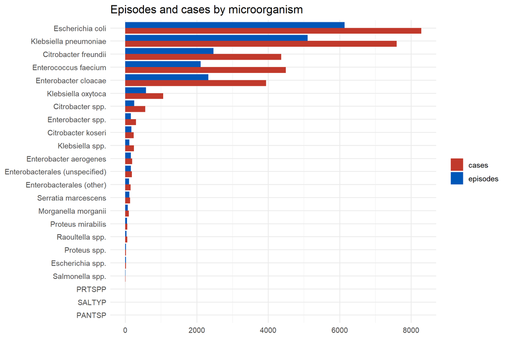

```r
by_sp %>% pivot_longer(c(episodes, cases)) %>%
  ggplot(aes(fct_reorder(species, value), value, fill = name)) +
  geom_col(position = "dodge") + coord_flip() +
  labs(x = NULL, y = NULL, fill = NULL, title = "Episodes and cases by microorganism") +
  scale_fill_manual(values = c(episodes = "#0057B8", cases = "#C1392B"))
```

## 11.2 Top species over time

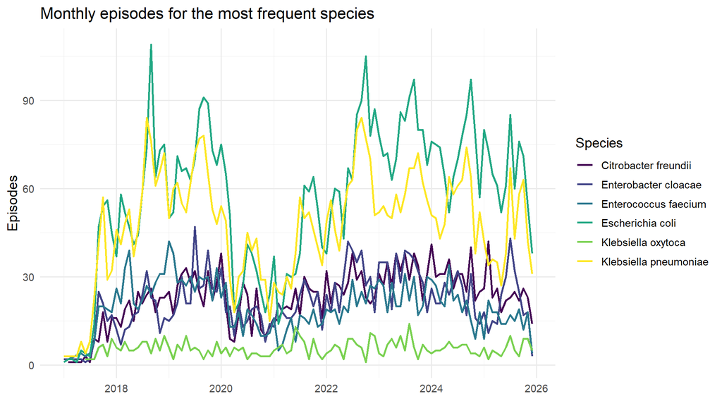

```r
top_sp <- by_sp$species[seq_len(min(6, nrow(by_sp)))]
epi_sp %>% filter(species %in% top_sp) %>% count(month, species, name = "episodes") %>%
  ggplot(aes(month, episodes, color = species)) + geom_line(linewidth = 0.8) +
  labs(x = NULL, y = "Episodes", color = "Species",
       title = "Monthly episodes for the most frequent species") +
  scale_color_viridis_d()
```

# 12 Mapping Episodes and Case Counts of France

Regions are matched to boundary polygons by a normalised region key. (Requires internet the first time, to download boundaries via `giscoR`.) Previous studies have shown that SPARES data underestimated the incidence by 1/3.

```r
region_key <- function(x) toupper(stri_trans_general(str_replace_all(x, "[’'`\\- ]", ""),
                                                      "Latin-ASCII"))
reg_counts <- epi %>% filter(!is.na(region)) %>% group_by(region) %>%
  summarise(episodes = n(), cases = sum(cases), .groups = "drop") %>%
  mutate(rkey = region_key(region))

# The 13 new metropolitan regions are NUTS level 1 (level 2 = the old regions).
# Older NUTS names are harmonised to the current region names before keying.
nuts1_fix <- c(
  "ALSACECHAMPAGNEARDENNELORRAINE" = "GRANDEST",
  "AQUITAINELIMOUSINPOITOUCHARENTES" = "NOUVELLEAQUITAINE",
  "LANGUEDOCROUSSILLONMIDIPYRENEES" = "OCCITANIE",
  "NORDPASDECALAISPICARDIE" = "HAUTSDEFRANCE")

fr <- gisco_get_nuts(country = "FR", nuts_level = 1, year = "2021", resolution = "20") %>%
  st_transform(2154) %>%                       # Lambert-93 (metropolitan France)
  mutate(rkey = region_key(NAME_LATN),
         rkey = recode(rkey, !!!nuts1_fix))

fr_map <- fr %>% left_join(reg_counts, by = "rkey")
# If any region stays grey, inspect fr$NAME_LATN and extend nuts1_fix above.
```

## 12.1 Episodes by region

```r
ggplot(fr_map) +
  geom_sf(aes(fill = episodes), color = "white", linewidth = 0.2) +
  scale_fill_viridis_c(na.value = "grey90") +
  coord_sf(xlim = c(1e5, 1.3e6), ylim = c(6.0e6, 7.2e6)) +   # metropolitan window
  labs(title = "BHRe episodes by region", fill = "Episodes") +
  theme_void(base_size = 12)
```

[output not shown]

## 12.2 Cases by region

```r
ggplot(fr_map) +
  geom_sf(aes(fill = cases), color = "white", linewidth = 0.2) +
  scale_fill_viridis_c(option = "rocket", direction = -1, na.value = "grey90") +
  coord_sf(xlim = c(1e5, 1.3e6), ylim = c(6.0e6, 7.2e6)) +
  labs(title = "BHRe cases by region", fill = "Cases") +
  theme_void(base_size = 12)
```

[output not shown]

# 13 Save summary tables

```r
readr::write_csv(by_year,   here("Datasets","Output Data","bhre_by_year.csv"))
readr::write_csv(by_region, here("Datasets","Output Data","bhre_by_region.csv"))
readr::write_csv(by_mech,   here("Datasets","Output Data","bhre_by_mechanism.csv"))
readr::write_csv(by_sp,     here("Datasets","Output Data","bhre_by_species.csv"))
```

# 14 Regional, Type and Facility-Level Incidence of BHRE and CPOs

```r
library(stringi)
fin9 <- function(x) str_pad(str_extract(str_replace(as.character(x), "\\.0$", ""),
                                        "[0-9]+"), 9, pad = "0")

# --- flag carbapenemase-producer episodes -----------------------------------
# carbapenemases only: KPC/NDM/VIM/IMP/IMI, the OXA-48 group, and untyped
# "carbapénèmase" calls. Excludes GRE (Van A/B) and mcr.
carba_detect <- function(x) {
  if (is.na(x)) return(FALSE)
  u <- toupper(stri_trans_general(x, "Latin-ASCII"))
  str_detect(u, "^KPC|^NDM|^VIM|^IMP|^IMI|^OXA-48|OXA-48-LIKE|OXA-181|OXA-204|OXA-244|OXA-162|OXA-232|CARBAPENEMASE")
}

mech_all <- c("resistance_mechanism_1_1","resistance_mechanism_1_2",
              "resistance_mechanism_2_1","resistance_mechanism_2_2",
              "resistance_mechanism_3_1","resistance_mechanism_3_2")

carba_flag <- epi %>%
  select(ehesp_id, all_of(mech_all)) %>%
  pivot_longer(all_of(mech_all), values_to = "m") %>%
  filter(!is.na(m), m != "") %>%
  mutate(carb = map_lgl(m, carba_detect)) %>%
  group_by(ehesp_id) %>% summarise(is_carba = any(carb), .groups = "drop")

epi2 <- epi %>% left_join(carba_flag, by = "ehesp_id") %>%
  mutate(is_carba = coalesce(is_carba, FALSE))

# --- cases per facility (overall + carbapenemase-only) ----------------------
cases_fac <- epi2 %>%
  mutate(fin = fin9(facility_finess_code)) %>%
  group_by(fin) %>%
  summarise(cases_all      = sum(cases),
            cases_carba    = sum(cases[is_carba]),
            episodes_all   = n(),
            episodes_carba = sum(is_carba), .groups = "drop")

# --- merge with patient-days and compute incidence --------------------------
hosp <- read.csv(here("Datasets","Output Data","Enriched Facility Data","hospital_stats_los_census.csv")) %>%
  mutate(fin = fin9(finess_geo))

facility_incidence <- hosp %>%
  select(fin, finess_geo, facility_name_capact, region, facility_type_pmsi, pt_days_total) %>%
  left_join(cases_fac, by = "fin") %>%
  mutate(across(c(cases_all, cases_carba, episodes_all, episodes_carba),
                ~ coalesce(.x, 0L)),
         inc_all_per1000   = 1000 * cases_all   / pt_days_total,   # cases / patient-days
         inc_carba_per1000 = 1000 * cases_carba / pt_days_total) %>%
  filter(pt_days_total > 0)


# BHRe facilities with cases but NO patient-day denominator (dropped from the rate)
anti_join(cases_fac, hosp, by = "fin") %>% summarise(facilities = n(), cases = sum(cases_all))
```

| facilities | cases |
| --- | --- |
| 124 | 2571 |

```r
# sanity: overall pooled rate vs distribution of facility rates
facility_incidence %>%
  summarise(pooled = 1000 * sum(cases_all) / sum(pt_days_total),
            median_facility = median(inc_all_per1000),
            median_carba    = median(inc_carba_per1000[cases_carba > 0]))
```

| pooled | median_facility | median_carba |
| --- | --- | --- |
| 0.2732641 | 0 | 0.1309758 |

```r
# keep coordinates for the map (add if not already in facility_incidence)
facility_incidence <- facility_incidence %>%
  left_join(select(hosp, fin, longitude, latitude), by = "fin")

# pooled incidence helper: cases / patient-days * 1000, over any grouping
agg_inc <- function(df, ...) {
  df %>% group_by(...) %>%
    summarise(facilities = n(),
              cases_all   = sum(cases_all),
              cases_carba = sum(cases_carba),
              pt_days     = sum(pt_days_total),
              inc_all_per1000   = round(1000 * cases_all   / pt_days, 3),
              inc_carba_per1000 = round(1000 * cases_carba / pt_days, 3),
              .groups = "drop")



}
```

## 14.1 Grouped Cumulative Incidence by Region

```r
inc_region <- agg_inc(facility_incidence, region) %>% arrange(desc(inc_all_per1000))
knitr::kable(inc_region, caption = "Incidence per 1,000 patient-days by region",
             subtitle = "All BHRE and Carbapenemase Producing Organisms")
```

Incidence per 1,000 patient-days by region

| region | facilities | cases_all | cases_carba | pt_days | inc_all_per1000 | inc_carba_per1000 |
| --- | --- | --- | --- | --- | --- | --- |
| Hauts-de-France | 196 | 3926 | 3735 | 8191752 | 0.479 | 0.456 |
| Île-de-France | 331 | 7144 | 6275 | 16469804 | 0.434 | 0.381 |
| Auvergne-Rhône-Alpes | 275 | 3302 | 2947 | 10928453 | 0.302 | 0.270 |
| Grand-Est | 221 | 2381 | 1632 | 7993265 | 0.298 | 0.204 |
| Occitanie | 258 | 2133 | 1614 | 8942846 | 0.239 | 0.180 |
| Provence-Alpes-Côte d’Azur | 222 | 1990 | 1713 | 8309335 | 0.239 | 0.206 |
| Pays de la Loire | 123 | 1033 | 950 | 4640355 | 0.223 | 0.205 |
| Provence-Alpes-Côte d’Azur | 9 | 79 | 54 | 535872 | 0.147 | 0.101 |
| Normandie | 124 | 702 | 621 | 5028353 | 0.140 | 0.123 |
| Nouvelle-Aquitaine | 235 | 1186 | 772 | 8506843 | 0.139 | 0.091 |
| Centre-Val de Loire | 84 | 483 | 386 | 3532528 | 0.137 | 0.109 |
| Bretagne | 110 | 598 | 507 | 5112000 | 0.117 | 0.099 |
| Bourgogne-Franche-Comté | 118 | 468 | 426 | 4194618 | 0.112 | 0.102 |
| NA | 23 | 6 | 3 | 186086 | 0.032 | 0.016 |
| Corse | 361 | 0 | 0 | 9342376 | 0.000 | 0.000 |

## 14.2 Plotting Facility Level Incidence by type and group

## 14.3 Grouped Incidence by Facility Type

```r
inc_type <- agg_inc(facility_incidence, facility_type_pmsi) %>% arrange(desc(inc_all_per1000))
knitr::kable(inc_type, caption = "Incidence per 1,000 patient-days by facility type")
```

Incidence per 1,000 patient-days by facility type

| facility_type_pmsi | facilities | cases_all | cases_carba | pt_days | inc_all_per1000 | inc_carba_per1000 |
| --- | --- | --- | --- | --- | --- | --- |
| Cancer centre (CLCC) | 20 | 653 | 603 | 655091 | 0.997 | 0.920 |
| Regional/University hospital (CHR/U) | 157 | 8874 | 7709 | 17011792 | 0.522 | 0.453 |
| General public hospital (CH) | 1051 | 11417 | 9520 | 38597923 | 0.296 | 0.247 |
| Non-profit facility (PSPH/EBNL) | 454 | 2219 | 1918 | 15065454 | 0.147 | 0.127 |
| Private | 991 | 2263 | 1883 | 30440110 | 0.074 | 0.062 |
| NA | 17 | 5 | 2 | 144116 | 0.035 | 0.014 |

## 14.4 By Facility Type and Region

```r
inc_type_region <- agg_inc(facility_incidence, region, facility_type_pmsi)

# wide table (regions × types), overall incidence
inc_type_region %>%
  select(region, facility_type_pmsi, inc_all_per1000) %>%
  tidyr::pivot_wider(names_from = facility_type_pmsi, values_from = inc_all_per1000) %>%
  knitr::kable(caption = "Overall incidence per 1,000 patient-days by region × facility type")
```

Overall incidence per 1,000 patient-days by region × facility type

| region | Cancer centre (CLCC) | General public hospital (CH) | Non-profit facility (PSPH/EBNL) | Private | Regional/University hospital (CHR/U) | NA |
| --- | --- | --- | --- | --- | --- | --- |
| Auvergne-Rhône-Alpes | 1.475 | 0.336 | 0.133 | 0.135 | 0.523 | NA |
| Bourgogne-Franche-Comté | 0.149 | 0.143 | 0.006 | 0.027 | 0.189 | NA |
| Bretagne | 0.093 | 0.148 | 0.012 | 0.026 | 0.245 | NA |
| Centre-Val de Loire | NA | 0.173 | 0.003 | 0.046 | 0.267 | NA |
| Corse | NA | 0.000 | NA | 0.000 | NA | NA |
| Grand-Est | 0.358 | 0.542 | 0.094 | 0.024 | 0.285 | NA |
| Hauts-de-France | 0.305 | 0.629 | 0.166 | 0.091 | 1.001 | NA |
| Normandie | 0.679 | 0.125 | 0.014 | 0.021 | 0.453 | NA |
| Nouvelle-Aquitaine | 0.164 | 0.225 | 0.040 | 0.026 | 0.198 | NA |
| Occitanie | 0.823 | 0.267 | 0.060 | 0.133 | 0.555 | NA |
| Pays de la Loire | 0.220 | 0.129 | 0.030 | 0.055 | 0.768 | NA |
| Provence-Alpes-Côte d’Azur | NA | 0.555 | 0.027 | 0.000 | 0.000 | NA |
| Provence-Alpes-Côte d’Azur | 0.949 | 0.364 | 0.339 | 0.071 | 0.390 | NA |
| Île-de-France | 1.868 | 0.485 | 0.355 | 0.142 | 0.744 | NA |
| NA | NA | NA | 0.108 | 0.000 | NA | 0.035 |

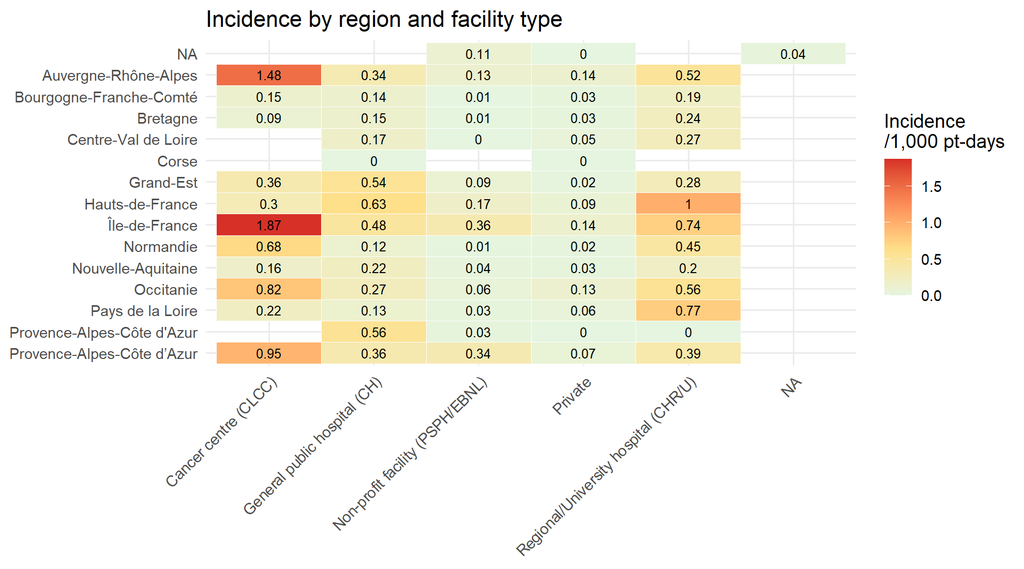

```r
# heatmap
inc_type_region %>%
  ggplot(aes(facility_type_pmsi, forcats::fct_rev(region), fill = inc_all_per1000)) +
  geom_tile(color = "white") +
  geom_text(aes(label = round(inc_all_per1000, 2)), size = 3) +
  scale_fill_gradientn(colours = c("#E5F5E0", "#FEE08B", "#FC8D59", "#D73027"),
                       na.value = "grey92") +
  labs(x = NULL, y = NULL, fill = "Incidence\n/1,000 pt-days",
       title = "Incidence by region and facility type") +
  theme_minimal(base_size = 12) +
  theme(axis.text.x = element_text(angle = 45, hjust = 1))
```

## 14.5 Facility-Level Incidence

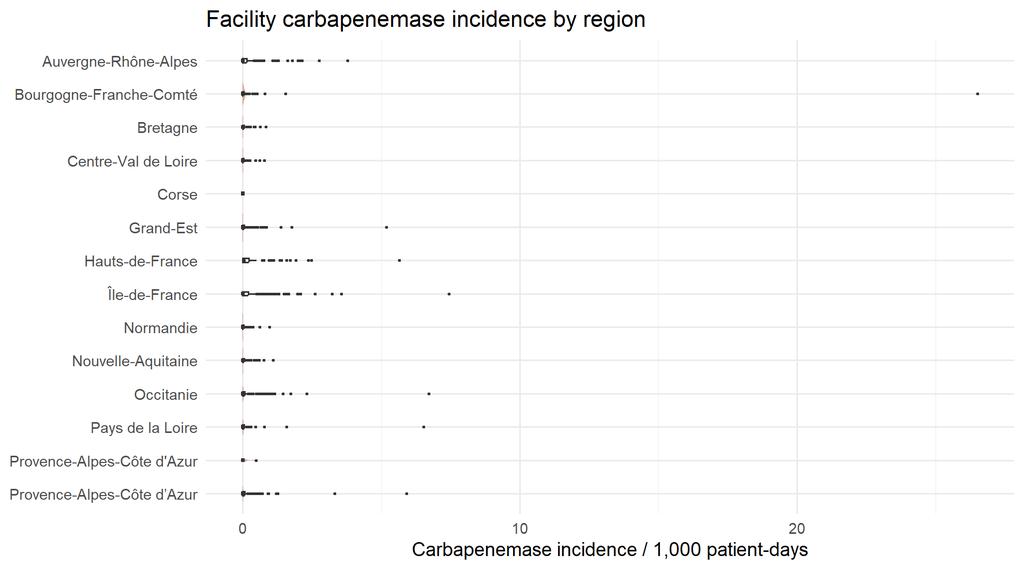

```r
inc_carba_fac <- facility_incidence %>%
  filter(pt_days_total > 0, !is.na(region))

inc_carba_fac %>%
  ggplot(aes(forcats::fct_rev(region), inc_carba_per1000)) +
  geom_violin(fill = "#C1392B", alpha = 0.4, color = NA) +
  geom_boxplot(width = 0.12, outlier.size = 0.5) +
  coord_flip() +
  labs(x = NULL, y = "Carbapenemase incidence / 1,000 patient-days",
       title = "Facility carbapenemase incidence by region") +
  theme_minimal(base_size = 12)
```

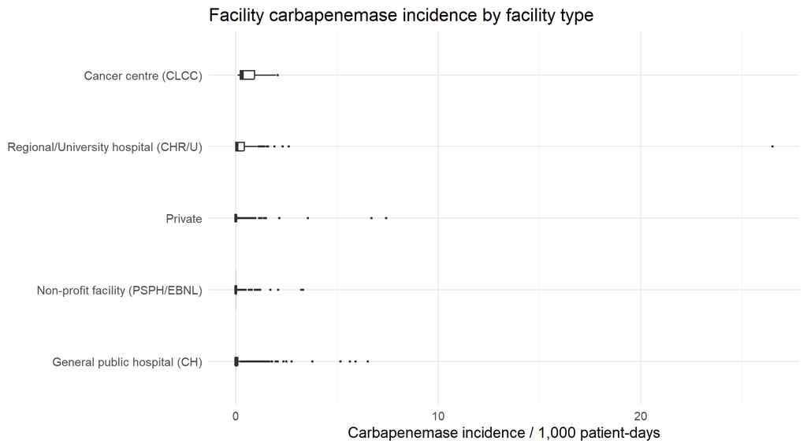

```r
inc_carba_fac %>%
  ggplot(aes(fct_reorder(facility_type_pmsi, inc_carba_per1000, median),
             inc_carba_per1000)) +
  geom_violin(fill = "#C1392B", alpha = 0.4, color = NA) +
  geom_boxplot(width = 0.12, outlier.size = 0.5) +
  coord_flip() +
  labs(x = NULL, y = "Carbapenemase incidence / 1,000 patient-days",
       title = "Facility carbapenemase incidence by facility type") +
  theme_minimal(base_size = 12)
```

## 14.6 Mapping Facility-Level Incidence Over the Map of France

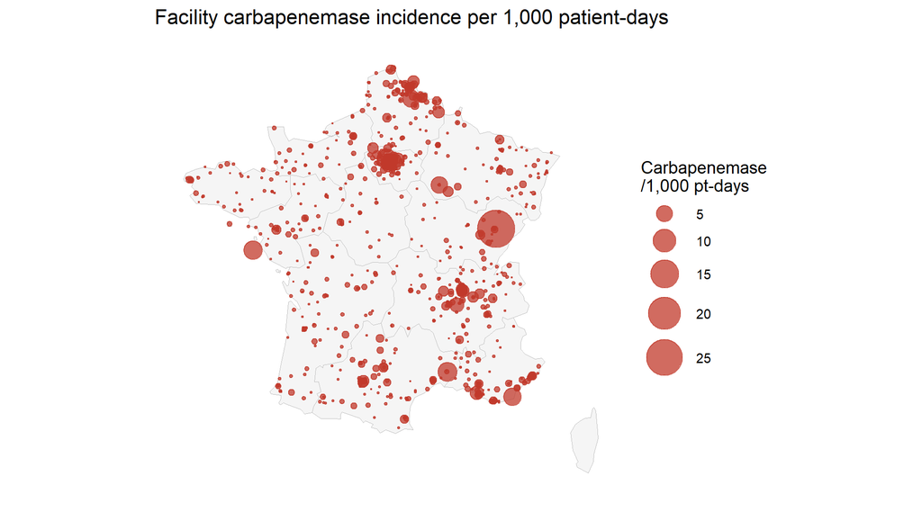

```r
library(sf); library(giscoR)
fr <- gisco_get_nuts(country = "FR", nuts_level = 1, year = "2021", resolution = "20")

map_carba <- facility_incidence %>%
  filter(!is.na(longitude), !is.na(latitude),
         is.finite(inc_carba_per1000), inc_carba_per1000 > 0)

ggplot() +
  geom_sf(data = fr, fill = "grey96", color = "grey75", linewidth = 0.2) +
  geom_point(data = map_carba,
             aes(longitude, latitude, size = inc_carba_per1000),
             color = "#C1392B", alpha = 0.75) +
  scale_size_area(max_size = 12, name = "Carbapenemase\n/1,000 pt-days") +
  coord_sf(xlim = c(-5, 10), ylim = c(41, 51.5)) +
  labs(title = "Facility carbapenemase incidence per 1,000 patient-days") +
  theme_void(base_size = 12)
```

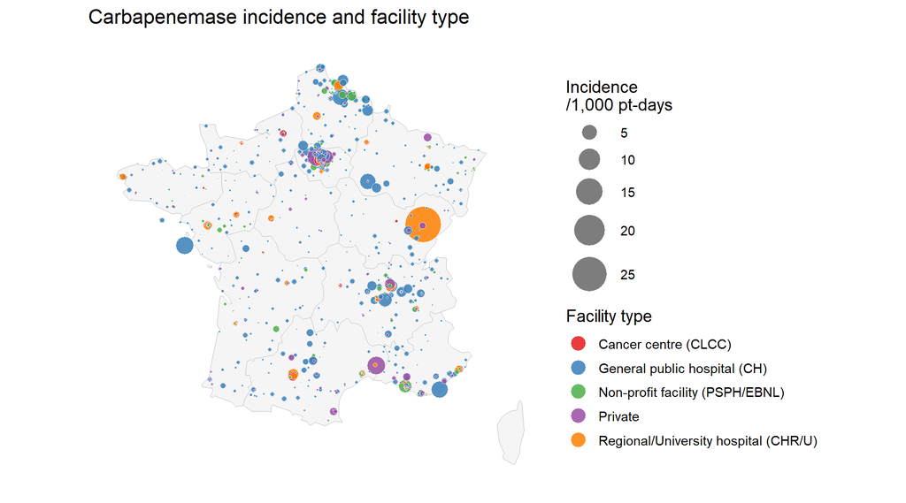

```r
map_carba <- facility_incidence %>%
  filter(!is.na(longitude), !is.na(latitude),
         is.finite(inc_carba_per1000), inc_carba_per1000 > 0,
         !is.na(facility_type_pmsi))
ggplot() +
  geom_sf(data = fr, fill = "grey96", color = "grey75", linewidth = 0.2) +
  geom_point(data = map_carba,
             aes(longitude, latitude,
                 size = inc_carba_per1000, fill = facility_type_pmsi),
             shape = 21, color = "white", stroke = 0.3, alpha = 0.85) +
  scale_size_area(max_size = 12, name = "Incidence\n/1,000 pt-days") +
  scale_fill_brewer(palette = "Set1", name = "Facility type") +
  coord_sf(xlim = c(-5, 10), ylim = c(41, 51.5)) +
  labs(title = "Carbapenemase incidence and facility type") +
  theme_void(base_size = 12) +
  guides(
    size = guide_legend(order = 1, override.aes = list(fill = "grey40", shape = 21)),
    fill = guide_legend(order = 2, override.aes = list(size = 5))
  )
```

## 14.7 final Notes

- **Cases** default to 1 when `n_total_if_secondary_cases` is missing, so cases ≥ episodes by construction.
- **Facility type** uses `params$facility_type_col` (facility_type_pmsi); switch to `hospital_type` for the MCO / SSR / MCO-SSR care grouping.
- Mechanism and species breakdowns count an episode under **each** family/species it carries, so those totals can exceed the overall episode count.
- Regions failing to match the map (e.g. overseas territories not in the metropolitan window) appear grey; adjust `region_key()` or the `coord_sf` window if needed.